# HURRICANE and TORNADO are the most dangerous natural disaster in the USA

E. Slavyaninov

13 декабря 2018 г

# Synopsis

In this project I analysed data from the U.S. National Oceanic and Atmospheric Administration’s storm database, that tracks characteristics of major storms and weather events in the United States. The goal was to answer the question, what types of events were the most harmful for population health and for the economy. During processing I detected and transform an outlier - the economic damage from the flood in California in 2006. As a result, the most harmful event with respect to population health turned out TORNADO, the greatest economic consequences were from HURRICANE.

# Loading and Processing Data

First, load library tidyverse, download date (if it wasn’t done before) and read it.

```r
library(tidyverse)
if (!any(grepl("StormData.csv.bz2",list.files()))) {
    File="https://d396qusza40orc.cloudfront.net/repdata%2Fdata%2FStormData.csv.bz2"
    download.file(File, "StormData.csv.bz2")
}
StormData<-read_csv("StormData.csv.bz2")
```

```r
StormData$Year<-as.numeric(format(as.Date(StormData$BGN_DATE,"%m/%d/%Y"), "%Y"))
mutate(StormData, TotEconDMG=case_when(PROPDMGEXP=="K"~10^3, PROPDMGEXP=="M"~10^6,
    PROPDMGEXP=="B"~10^9,TRUE~0)* PROPDMG+case_when(CROPDMGEXP=="K"~10^3, CROPDMGEXP=="M"~10^6,
    CROPDMGEXP=="B"~10^9, TRUE ~0)*CROPDMG, TotCasDMG=FATALITIES+INJURIES) %>%
    select(STATE,Year,EVTYPE,TotEconDMG,TotCasDMG)->StormDataProc
```

Сheck maximum values for casualty and economic damage

```r
StormDataProc %>% arrange(-TotCasDMG)
```

```
## # A tibble: 902,297 x 5
##    STATE  Year EVTYPE            TotEconDMG TotCasDMG
##    <chr> <dbl> <chr>                  <dbl>     <dbl>
##  1 TX     1979 TORNADO            250000000      1742
##  2 OH     1994 ICE STORM           55000000      1569
##  3 MA     1953 TORNADO            250000000      1318
##  4 MO     2011 TORNADO           2800000000      1308
##  5 OH     1974 TORNADO            250000000      1186
##  6 MI     1953 TORNADO             25000000       901
##  7 AL     2011 TORNADO           1500000000       844
##  8 TX     1998 FLOOD               50050000       802
##  9 FL     2004 HURRICANE/TYPHOON 5705000000       787
## 10 TX     1998 FLOOD              269550000       750
## # ... with 902,287 more rows
```

```r
StormDataProc %>% arrange(-TotEconDMG)
```

```
## # A tibble: 902,297 x 5
##    STATE  Year EVTYPE              TotEconDMG TotCasDMG
##    <chr> <dbl> <chr>                    <dbl>     <dbl>
##  1 CA     2006 FLOOD             115032500000         0
##  2 LA     2005 STORM SURGE        31300000000         0
##  3 LA     2005 HURRICANE/TYPHOON  16930000000         0
##  4 MS     2005 STORM SURGE        11260000000         0
##  5 IL     1993 RIVER FLOOD        10000000000         0
##  6 FL     2005 HURRICANE/TYPHOON  10000000000         5
##  7 MS     2005 HURRICANE/TYPHOON   7390000000       119
##  8 MS     2005 HURRICANE/TYPHOON   7350000000         0
##  9 FL     2004 HURRICANE/TYPHOON   5705000000       787
## 10 TX     2001 TROPICAL STORM      5150000000        22
## # ... with 902,287 more rows
```

The first entry in economic damage looked pretty big, so I googled the economic damage from the flood in California in 2006, and found it was about 100 mln $, not 100 bln. In my opinion it was outlier (becouse of wrong unit), so I edited it. Double check after that

```r
StormDataProc$TotEconDMG[which.max(StormDataProc$TotEconDMG)]<-
    StormDataProc$TotEconDMG[which.max(StormDataProc$TotEconDMG)]/10^3
StormDataProc %>% arrange(-TotEconDMG)
```

```
## # A tibble: 902,297 x 5
##    STATE  Year EVTYPE             TotEconDMG TotCasDMG
##    <chr> <dbl> <chr>                   <dbl>     <dbl>
##  1 LA     2005 STORM SURGE       31300000000         0
##  2 LA     2005 HURRICANE/TYPHOON 16930000000         0
##  3 MS     2005 STORM SURGE       11260000000         0
##  4 IL     1993 RIVER FLOOD       10000000000         0
##  5 FL     2005 HURRICANE/TYPHOON 10000000000         5
##  6 MS     2005 HURRICANE/TYPHOON  7390000000       119
##  7 MS     2005 HURRICANE/TYPHOON  7350000000         0
##  8 FL     2004 HURRICANE/TYPHOON  5705000000       787
##  9 TX     2001 TROPICAL STORM     5150000000        22
## 10 MS     1994 ICE STORM          5000500000         0
## # ... with 902,287 more rows
```

# Results

Summarize top 4 types of damages with the largest values. I put them in the tables (TopCasDMG and TopEconDMG) and brought to the screen.

```r
StormDataProc %>% group_by(EVTYPE) %>% summarise(CasDMG=sum(TotCasDMG),EconDMG=sum(TotEconDMG))%>%
    select(EVTYPE, CasDMG) %>% mutate(EVTYPE2 = EVTYPE) %>% arrange(-CasDMG) %>% head(4)->TopCasDMG
StormDataProc %>% group_by(EVTYPE) %>% summarise(CasDMG=sum(TotCasDMG),EconDMG=sum(TotEconDMG))%>%
    select(EVTYPE, EconDMG)%>% mutate(EVTYPE2 = EVTYPE) %>% arrange(-EconDMG) %>% head(4)->TopEconDMG
TopCasDMG[,1:2]
```

```
## # A tibble: 4 x 2
##   EVTYPE         CasDMG
##   <chr>           <dbl>
## 1 TORNADO         96979
## 2 EXCESSIVE HEAT   8428
## 3 TSTM WIND        7461
## 4 FLOOD            7259
```

```r
TopEconDMG[,1:2]
```

```
## # A tibble: 4 x 2
##   EVTYPE                EconDMG
##   <chr>                   <dbl>
## 1 HURRICANE/TYPHOON 71913712800
## 2 TORNADO           57340613590
## 3 STORM SURGE       43323541000
## 4 FLOOD             35402210750
```

For a broader analysis I made some graphics of top types of events.

- *Boxplot for economic damage on the logarithmic scale*

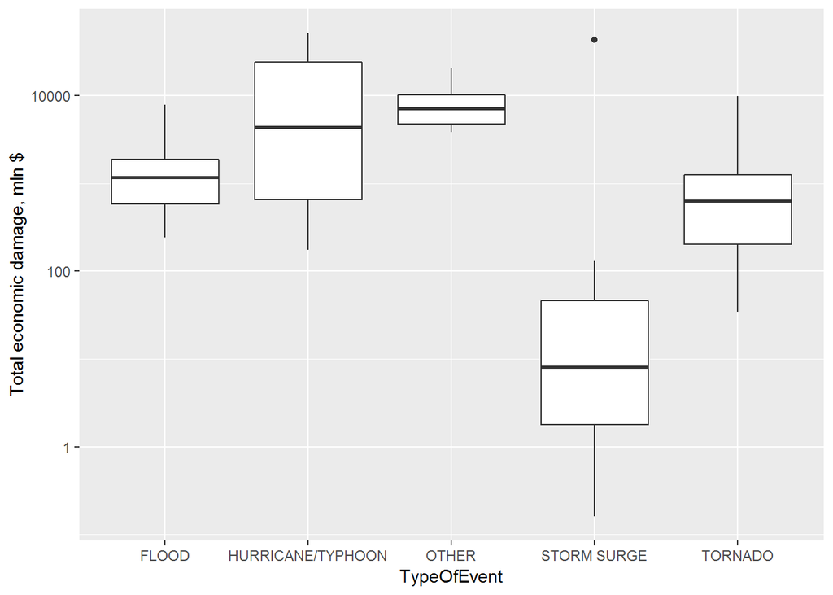

```r
StormDataProc %>% left_join(TopEconDMG)%>% mutate(TypeOfEvent=if_else(is.na(EVTYPE2), "OTHER", EVTYPE2)) %>%
    group_by(Year,TypeOfEvent) %>% summarise(TotEconDMG=sum(TotEconDMG)/10^6) %>%
    ggplot(aes(TypeOfEvent, TotEconDMG))+geom_boxplot()+scale_y_log10()+ylab("Total economic damage, mln $")
```

- *Time series plot for casualties damage.*

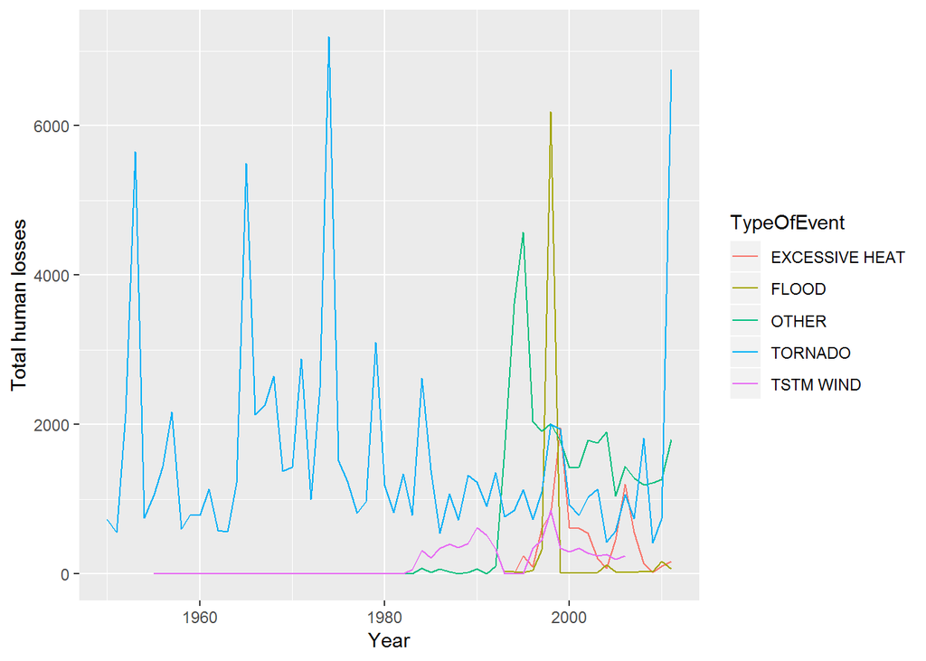

```r
StormDataProc %>% left_join(TopCasDMG)%>% mutate(TypeOfEvent=if_else(is.na(EVTYPE2), "OTHER", EVTYPE2)) %>%
    group_by(Year,TypeOfEvent) %>% summarise(TotCasDMG=sum(TotCasDMG)) %>%
    ggplot(aes(Year,TotCasDMG))+geom_line(aes(col=TypeOfEvent))+ylab("Total human losses")
```

TORNADO was the most harmful for most years but it seems that until the mid-eighties most other events were not logged. Lets check economic and casualties damage which happened after 1985.

```r
StormDataProc %>% filter(Year>1985) %>% group_by(EVTYPE) %>%
    summarise(TotEconDMG=sum(TotEconDMG)) %>% arrange(-TotEconDMG) %>% head(5)
```

```
## # A tibble: 5 x 2
##   EVTYPE             TotEconDMG
##   <chr>                   <dbl>
## 1 HURRICANE/TYPHOON 71913712800
## 2 STORM SURGE       43323541000
## 3 FLOOD             35402210750
## 4 TORNADO           35188984410
## 5 HAIL              18752904170
```

```r
StormDataProc %>% filter(Year>1985) %>% group_by(EVTYPE) %>%
    summarise(TotCasDMG=sum(TotCasDMG)) %>% arrange(-TotCasDMG) %>% head(5)
```

```
## # A tibble: 5 x 2
##   EVTYPE         TotCasDMG
##   <chr>              <dbl>
## 1 TORNADO            32094
## 2 EXCESSIVE HEAT      8428
## 3 FLOOD               7259
## 4 TSTM WIND           6863
## 5 LIGHTNING           6046
```

**As can be seen from the new values, the most harmful types of events don’t change.**